# EasyVisa Project

## Context:

Business communities in the United States are facing high demand for human resources, but one of the constant challenges is identifying and attracting the right talent, which is perhaps the most important element in remaining competitive. Companies in the United States look for hard-working, talented, and qualified individuals both locally as well as abroad.

The Immigration and Nationality Act (INA) of the US permits foreign workers to come to the United States to work on either a temporary or permanent basis. The act also protects US workers against adverse impacts on their wages or working conditions by ensuring US employers' compliance with statutory requirements when they hire foreign workers to fill workforce shortages. The immigration programs are administered by the Office of Foreign Labor Certification (OFLC).

OFLC processes job certification applications for employers seeking to bring foreign workers into the United States and grants certifications in those cases where employers can demonstrate that there are not sufficient US workers available to perform the work at wages that meet or exceed the wage paid for the occupation in the area of intended employment.

## Objective:

In FY 2016, the OFLC processed 775,979 employer applications for 1,699,957 positions for temporary and permanent labor certifications. This was a nine percent increase in the overall number of processed applications from the previous year. The process of reviewing every case is becoming a tedious task as the number of applicants is increasing every year.

The increasing number of applicants every year calls for a Machine Learning based solution that can help in shortlisting the candidates having higher chances of VISA approval. OFLC has hired your firm EasyVisa for data-driven solutions. You as a data scientist have to analyze the data provided and, with the help of a classification model:

- Facilitate the process of visa approvals.
- Recommend a suitable profile for the applicants for whom the visa should be certified or denied based on the drivers that significantly influence the case status.

## Data Description

The data contains the different attributes of the employee and the employer. The detailed data dictionary is given below.

- case_id: ID of each visa application
- continent: Information of continent the employee
- education_of_employee: Information of education of the employee
- has_job_experience: Does the employee has any job experience? Y= Yes; N = No
- requires_job_training: Does the employee require any job training? Y = Yes; N = No
- no_of_employees: Number of employees in the employer's company
- yr_of_estab: Year in which the employer's company was established
- region_of_employment: Information of foreign worker's intended region of employment in the US.
- prevailing_wage: Average wage paid to similarly employed workers in a specific occupation in the area of intended employment. The purpose of the prevailing wage is to ensure that the foreign worker is not underpaid compared to other workers offering the same or similar service in the same area of employment.
- unit_of_wage: Unit of prevailing wage. Values include Hourly, Weekly, Monthly, and Yearly.
- full_time_position: Is the position of work full-time? Y = Full Time Position; N = Part Time Position
- case_status: Flag indicating if the Visa was certified or denied

## Importing necessary libraries and data

```python
# To filter the warnings
import warnings
warnings.filterwarnings("ignore")

# Libraries to help with reading and manipulating data
import pandas as pd
import numpy as np

# libaries to help with data visualization
import matplotlib.pyplot as plt
%matplotlib inline
import seaborn as sns

# Library to split data
from sklearn.model_selection import train_test_split

# To get grid search cv
from sklearn.model_selection import GridSearchCV

# To import DecisionTree
from sklearn.tree import DecisionTreeClassifier
from sklearn import tree

from sklearn import metrics
from sklearn.ensemble import BaggingClassifier, RandomForestClassifier
from sklearn.linear_model import LogisticRegression
from sklearn.ensemble import AdaBoostClassifier, GradientBoostingClassifier

#To install xgboost library use - !pip install xgboost
from xgboost import XGBClassifier

# To get diferent metric scores
from sklearn import metrics
from sklearn.metrics import accuracy_score, roc_curve, confusion_matrix, roc_auc_score,f1_score, precision_score, recall_score,precision_recall_curve,make_scorer
```

## Data Overview

- Observations
- Sanity checks

```python
# Loading the dataset

from google.colab import drive
drive.mount('/content/drive')

# read the data
path="/content/drive/MyDrive/Data Science/EasyVisa.csv"
evisa_df = pd.read_csv(path)
# returns the first 5 rows
evisa_df.head()
```

|  | case_id | continent | education_of_employee | has_job_experience | requires_job_training | no_of_employees | yr_of_estab | region_of_employment | prevailing_wage | unit_of_wage | full_time_position | case_status |
| --- | --- | --- | --- | --- | --- | --- | --- | --- | --- | --- | --- | --- |
| 0 | EZYV01 | Asia | High School | N | N | 14513 | 2007 | West | 592.2029 | Hour | Y | Denied |
| 1 | EZYV02 | Asia | Master's | Y | N | 2412 | 2002 | Northeast | 83425.6500 | Year | Y | Certified |
| 2 | EZYV03 | Asia | Bachelor's | N | Y | 44444 | 2008 | West | 122996.8600 | Year | Y | Denied |
| 3 | EZYV04 | Asia | Bachelor's | N | N | 98 | 1897 | West | 83434.0300 | Year | Y | Denied |
| 4 | EZYV05 | Africa | Master's | Y | N | 1082 | 2005 | South | 149907.3900 | Year | Y | Certified |

```python
# Shape of the data set
evisa_df.shape
```

```
(25480, 12)
```

**Evisa dataset has 25480 rows and 12 columns.**

```python
# Data type and null count of the dataset
evisa_df.info()
```

```
<class 'pandas.core.frame.DataFrame'>
RangeIndex: 25480 entries, 0 to 25479
Data columns (total 12 columns):
 #   Column                 Non-Null Count  Dtype
---  ------                 --------------  -----
 0   case_id                25480 non-null  object
 1   continent              25480 non-null  object
 2   education_of_employee  25480 non-null  object
 3   has_job_experience     25480 non-null  object
 4   requires_job_training  25480 non-null  object
 5   no_of_employees        25480 non-null  int64
 6   yr_of_estab            25480 non-null  int64
 7   region_of_employment   25480 non-null  object
 8   prevailing_wage        25480 non-null  float64
 9   unit_of_wage           25480 non-null  object
 10  full_time_position     25480 non-null  object
 11  case_status            25480 non-null  object
dtypes: float64(1), int64(2), object(9)
memory usage: 2.3+ MB
```

no_of_employees,yr_of_estab - **int datatype**

prevailing_wage - **float datatype**

```python
evisa_df.isna().sum()
```

```
case_id                  0
continent                0
education_of_employee    0
has_job_experience       0
requires_job_training    0
no_of_employees          0
yr_of_estab              0
region_of_employment     0
prevailing_wage          0
unit_of_wage             0
full_time_position       0
case_status              0
dtype: int64
```

**There are no missing values in the dataset**

```python
# Checking duplicates
evisa_df.duplicated().sum()
```

```
0
```

**There are no duplicates in the dataset**

```python
# Creating copy of the dataset
evisa_df2 = evisa_df.copy()
```

```python
# Summary of the dataset
evisa_df.describe(include='all').T
```

|  | count | unique | top | freq | mean | std | min | 25% | 50% | 75% | max |
| --- | --- | --- | --- | --- | --- | --- | --- | --- | --- | --- | --- |
| case_id | 25480 | 25480 | EZYV01 | 1 | NaN | NaN | NaN | NaN | NaN | NaN | NaN |
| continent | 25480 | 6 | Asia | 16861 | NaN | NaN | NaN | NaN | NaN | NaN | NaN |
| education_of_employee | 25480 | 4 | Bachelor's | 10234 | NaN | NaN | NaN | NaN | NaN | NaN | NaN |
| has_job_experience | 25480 | 2 | Y | 14802 | NaN | NaN | NaN | NaN | NaN | NaN | NaN |
| requires_job_training | 25480 | 2 | N | 22525 | NaN | NaN | NaN | NaN | NaN | NaN | NaN |
| no_of_employees | 25480.0 | NaN | NaN | NaN | 5667.04321 | 22877.928848 | -26.0 | 1022.0 | 2109.0 | 3504.0 | 602069.0 |
| yr_of_estab | 25480.0 | NaN | NaN | NaN | 1979.409929 | 42.366929 | 1800.0 | 1976.0 | 1997.0 | 2005.0 | 2016.0 |
| region_of_employment | 25480 | 5 | Northeast | 7195 | NaN | NaN | NaN | NaN | NaN | NaN | NaN |
| prevailing_wage | 25480.0 | NaN | NaN | NaN | 74455.814592 | 52815.942327 | 2.1367 | 34015.48 | 70308.21 | 107735.5125 | 319210.27 |
| unit_of_wage | 25480 | 4 | Year | 22962 | NaN | NaN | NaN | NaN | NaN | NaN | NaN |
| full_time_position | 25480 | 2 | Y | 22773 | NaN | NaN | NaN | NaN | NaN | NaN | NaN |
| case_status | 25480 | 2 | Certified | 17018 | NaN | NaN | NaN | NaN | NaN | NaN | NaN |

### **Observation from data**

Evisa dataset has 25480 rows and 12 columns. It does not have any missing values.

```python
# Dropping case_id column
evisa_df.drop('case_id',axis=1,inplace=True)
```

```python
# Creating column for finding how many years since company establishment
evisa_df['yrs_since_estab'] = evisa_df['yr_of_estab'].max() - evisa_df['yr_of_estab']
evisa_df.head()
```

|  | continent | education_of_employee | has_job_experience | requires_job_training | no_of_employees | yr_of_estab | region_of_employment | prevailing_wage | unit_of_wage | full_time_position | case_status | yrs_since_estab |
| --- | --- | --- | --- | --- | --- | --- | --- | --- | --- | --- | --- | --- |
| 0 | Asia | High School | N | N | 14513 | 2007 | West | 592.2029 | Hour | Y | Denied | 9 |
| 1 | Asia | Master's | Y | N | 2412 | 2002 | Northeast | 83425.6500 | Year | Y | Certified | 14 |
| 2 | Asia | Bachelor's | N | Y | 44444 | 2008 | West | 122996.8600 | Year | Y | Denied | 8 |
| 3 | Asia | Bachelor's | N | N | 98 | 1897 | West | 83434.0300 | Year | Y | Denied | 119 |
| 4 | Africa | Master's | Y | N | 1082 | 2005 | South | 149907.3900 | Year | Y | Certified | 11 |

```python
# Function to calculate prevailing wage on yearly basis
def wage_year(x,y):
    if x == 'Hour':
         return y*40*52
    elif x == 'Week':
         return y*52
    elif x == 'Month':
         return y*12
    else:
         return y
```

```python
# Applying function to calculate prevailing wage in yearly
evisa_df['Yearly_wage'] = evisa_df.apply(lambda x: wage_year(x['unit_of_wage'],x['prevailing_wage']),axis=1)
```

```python
# Checking different counts of categorical variables in dataset
for i in evisa_df.columns:
    if evisa_df[i].dtypes == object:
        print('There are',evisa_df[i].nunique(),'Different type of', i ,'for the easy visa dataset and its counts in dataset as below')
        display()
        display(evisa_df[i].value_counts(normalize=True))
        display(evisa_df[i].value_counts())
        print('----------------------------------------------------------------------------')
```

```
There are 6 Different type of continent for the easy visa dataset and its counts in dataset as below
```

```
Asia             0.661735
Europe           0.146468
North America    0.129199
South America    0.033438
Africa           0.021625
Oceania          0.007535
Name: continent, dtype: float64
```

```
Asia             16861
Europe            3732
North America     3292
South America      852
Africa             551
Oceania            192
Name: continent, dtype: int64
```

```
----------------------------------------------------------------------------
There are 4 Different type of education_of_employee for the easy visa dataset and its counts in dataset as below
```

```
Bachelor's     0.401648
Master's       0.378100
High School    0.134223
Doctorate      0.086028
Name: education_of_employee, dtype: float64
```

```
Bachelor's     10234
Master's        9634
High School     3420
Doctorate       2192
Name: education_of_employee, dtype: int64
```

```
----------------------------------------------------------------------------
There are 2 Different type of has_job_experience for the easy visa dataset and its counts in dataset as below
```

```
Y    0.580926
N    0.419074
Name: has_job_experience, dtype: float64
```

```
Y    14802
N    10678
Name: has_job_experience, dtype: int64
```

```
----------------------------------------------------------------------------
There are 2 Different type of requires_job_training for the easy visa dataset and its counts in dataset as below
```

```
N    0.884027
Y    0.115973
Name: requires_job_training, dtype: float64
```

```
N    22525
Y     2955
Name: requires_job_training, dtype: int64
```

```
----------------------------------------------------------------------------
There are 5 Different type of region_of_employment for the easy visa dataset and its counts in dataset as below
```

```
Northeast    0.282378
South        0.275392
West         0.258477
Midwest      0.169035
Island       0.014717
Name: region_of_employment, dtype: float64
```

```
Northeast    7195
South        7017
West         6586
Midwest      4307
Island        375
Name: region_of_employment, dtype: int64
```

```
----------------------------------------------------------------------------
There are 4 Different type of unit_of_wage for the easy visa dataset and its counts in dataset as below
```

```
Year     0.901177
Hour     0.084655
Week     0.010675
Month    0.003493
Name: unit_of_wage, dtype: float64
```

```
Year     22962
Hour      2157
Week       272
Month       89
Name: unit_of_wage, dtype: int64
```

```
----------------------------------------------------------------------------
There are 2 Different type of full_time_position for the easy visa dataset and its counts in dataset as below
```

```
Y    0.89376
N    0.10624
Name: full_time_position, dtype: float64
```

```
Y    22773
N     2707
Name: full_time_position, dtype: int64
```

```
----------------------------------------------------------------------------
There are 2 Different type of case_status for the easy visa dataset and its counts in dataset as below
```

```
Certified    0.667896
Denied       0.332104
Name: case_status, dtype: float64
```

```
Certified    17018
Denied        8462
Name: case_status, dtype: int64
```

```python
# Function to convert negative no of employees to positive
def positive(s):
    if s < 0:
        return s * -1
    else:
        return s
```

```python
# Applying function to no_of_employees
evisa_df['no_of_employees'] = evisa_df['no_of_employees'].apply(positive)
```

```python
# Summary of the dataset
evisa_df.describe(include='all').T
```

|  | count | unique | top | freq | mean | std | min | 25% | 50% | 75% | max |
| --- | --- | --- | --- | --- | --- | --- | --- | --- | --- | --- | --- |
| continent | 25480 | 6 | Asia | 16861 | NaN | NaN | NaN | NaN | NaN | NaN | NaN |
| education_of_employee | 25480 | 4 | Bachelor's | 10234 | NaN | NaN | NaN | NaN | NaN | NaN | NaN |
| has_job_experience | 25480 | 2 | Y | 14802 | NaN | NaN | NaN | NaN | NaN | NaN | NaN |
| requires_job_training | 25480 | 2 | N | 22525 | NaN | NaN | NaN | NaN | NaN | NaN | NaN |
| no_of_employees | 25480.0 | NaN | NaN | NaN | 5667.089207 | 22877.917453 | 11.0 | 1022.0 | 2109.0 | 3504.0 | 602069.0 |
| yr_of_estab | 25480.0 | NaN | NaN | NaN | 1979.409929 | 42.366929 | 1800.0 | 1976.0 | 1997.0 | 2005.0 | 2016.0 |
| region_of_employment | 25480 | 5 | Northeast | 7195 | NaN | NaN | NaN | NaN | NaN | NaN | NaN |
| prevailing_wage | 25480.0 | NaN | NaN | NaN | 74455.814592 | 52815.942327 | 2.1367 | 34015.48 | 70308.21 | 107735.5125 | 319210.27 |
| unit_of_wage | 25480 | 4 | Year | 22962 | NaN | NaN | NaN | NaN | NaN | NaN | NaN |
| full_time_position | 25480 | 2 | Y | 22773 | NaN | NaN | NaN | NaN | NaN | NaN | NaN |
| case_status | 25480 | 2 | Certified | 17018 | NaN | NaN | NaN | NaN | NaN | NaN | NaN |
| yrs_since_estab | 25480.0 | NaN | NaN | NaN | 36.590071 | 42.366929 | 0.0 | 11.0 | 19.0 | 40.0 | 216.0 |
| Yearly_wage | 25480.0 | NaN | NaN | NaN | 197391.155259 | 578591.666314 | 100.0 | 47107.965 | 82839.46 | 124825.035 | 14569149.4 |

# **Exploratory Data Analysis (EDA)**

```python
# Getting percent on bar plot
def barplot_values_percent(ax):
    heightlst = []
    for i in ax.patches:
        heightlst.append(i.get_height())
    total = sum(heightlst)

    for i in ax.patches:
        x = i.get_x()+0.05 #adjust the numbers (higher numbers = to the right, lower = to the left)
        height = i.get_height()+0.1 #adjust the numbers (higher numbers = up, lower = down)
        value = ("{0:.2f}".format((i.get_height()/total)*100)+'%')

        ax.text(x, height, value, fontsize=10,color='red')
```

```python
# Getting median on box plot
import matplotlib.patheffects as path_effects

def add_median_labels(ax, fmt='.1f'):
    lines = ax.get_lines()
    boxes = [c for c in ax.get_children() if type(c).__name__ == 'PathPatch']
    lines_per_box = int(len(lines) / len(boxes))
    for median in lines[4:len(lines):lines_per_box]:
        x, y = (data.mean() for data in median.get_data())
        # choose value depending on horizontal or vertical plot orientation
        value = x if (median.get_xdata()[1] - median.get_xdata()[0]) == 0 else y
        text = ax.text(x, y, f'{value:{fmt}}', ha='center', va='center',
                       fontweight='bold', color='white')
        # create median-colored border around white text for contrast
        text.set_path_effects([
            path_effects.Stroke(linewidth=3, foreground=median.get_color()),
            path_effects.Normal(),
        ])
```

```python
# Histplot,boxplot and count plot function
def hist(fea,df,kde):
    sns.histplot(x=fea,data=df,kde=kde)
    plt.show()
def box(fea,df):
    ax = sns.boxplot(x=fea,data=df)
    add_median_labels(ax)
    plt.show()
def count(fea,df):
     ax = sns.countplot(x=fea,data=df)
     barplot_values_percent(ax)
     plt.show()
```

## **Univariate analysis of data**

```
(194, 13)
```

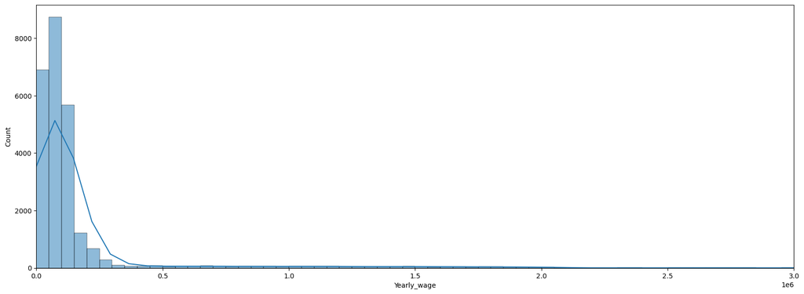

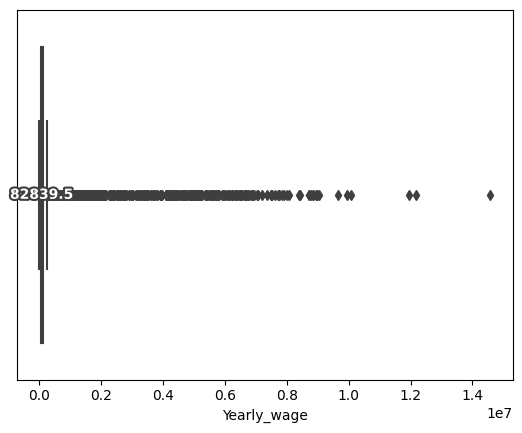

```python
# Univariate analysis for Yearly_wage
display(evisa_df[evisa_df['Yearly_wage'] > 3000000].shape)
plt.figure(figsize=(20, 7))
ax = sns.histplot(x='Yearly_wage',data=evisa_df,binwidth=50000,kde=True)
ax.set(xlim=(0,3000000))
plt.show()
box('Yearly_wage',evisa_df)
```

Median prevailing wage on yearly basis is dollar 82839.5.

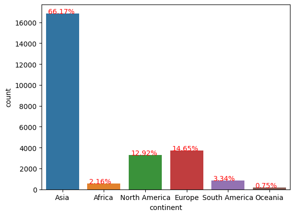

```python
# Univariate analysis for continent
count('continent',evisa_df)
```

As you can see almost 66.17% application is from Asia followed by 14.65% from Europe. Ocenia has only 0.75% application.

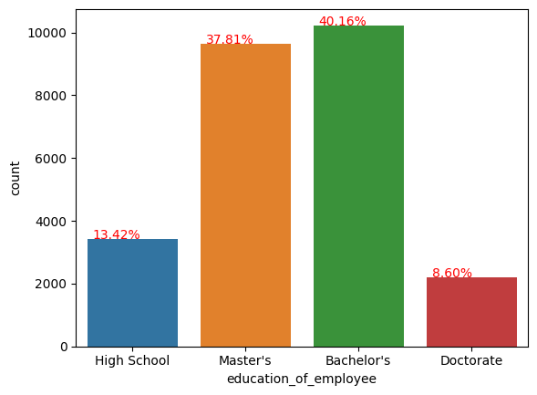

```python
# Univariate analysis for education_of_employee
count('education_of_employee',evisa_df)
```

As you can see 40.16% of applicant has Bacheloer's degree and 37.81% has Master's degree. Only 8.60% applicant has Doctorate degree.

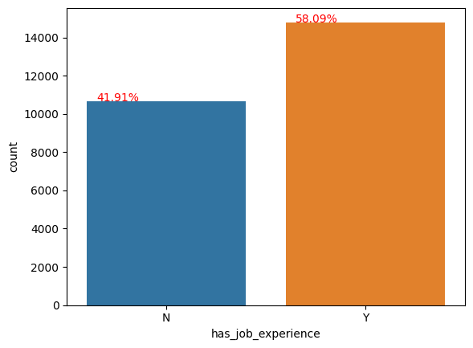

```python
# Univariate analysis for has_job_experience
count('has_job_experience',evisa_df)
```

Almost 58.09% applicant has job experience and remaining 41.91% applicant does not have any experience.

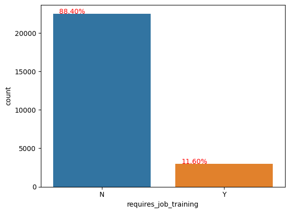

```python
# Univariate analysis for requires_job_training
count('requires_job_training',evisa_df)
```

Almost 88.40% applicant does not need any kind of job training and 11.60% applicant only needs job training.

```
(271, 13)
```

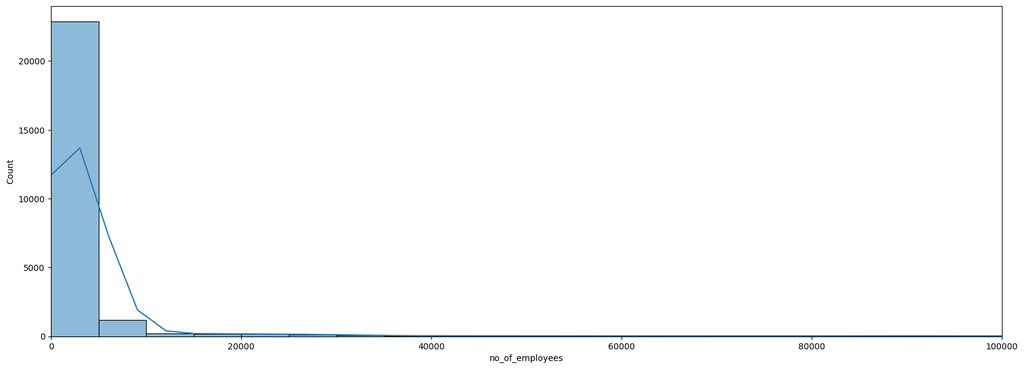

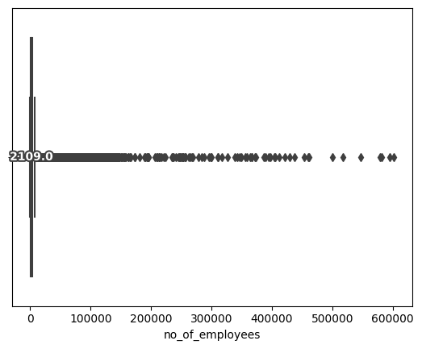

```python
# Univariate analysis for no of employees
display(evisa_df[evisa_df['no_of_employees'] > 100000].shape)
plt.figure(figsize=(20, 7))
ax = sns.histplot(x='no_of_employees',data=evisa_df,binwidth=5000,kde=True)
ax.set(xlim=(0,100000))
plt.show()
box('no_of_employees',evisa_df)
```

No_of_employees has an average value of 5667 and median values is 2109. It has minimum of 11 and maximum of 602069.

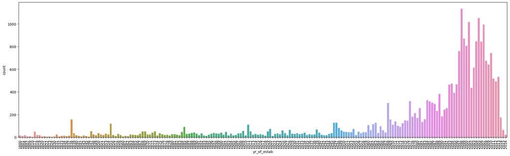

```python
# Univariate analysis for yr_of_estab
plt.figure(figsize=(25, 7))
sns.countplot(x='yr_of_estab',data=evisa_df)
plt.xticks(rotation=90);
```

As you can see most of the companies who applied for visa has been established between year 1993 and 2014. Data has year of establishment from 1800 to 2016.

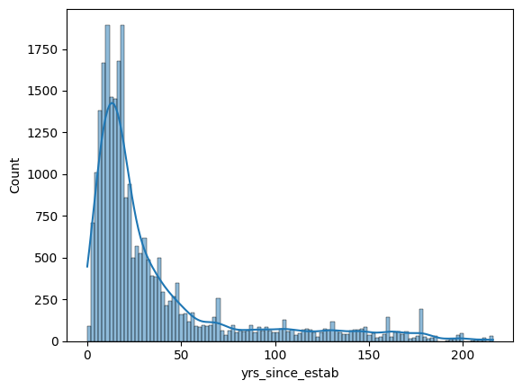

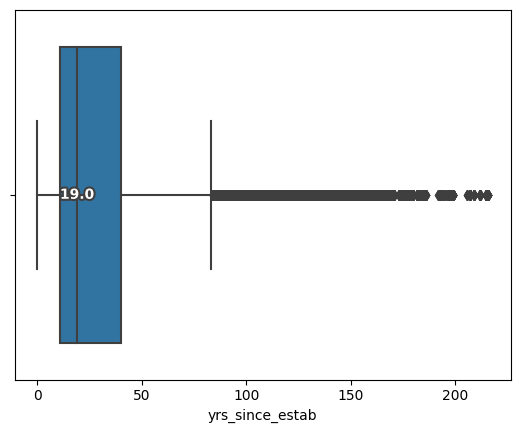

```python
# Univariate analysis for yrs_since_estab
hist('yrs_since_estab',evisa_df,True)
box('yrs_since_estab',evisa_df)
```

As you can see most of the companies has been in the market since 40 years. There are some companies which are more then 200 years old.

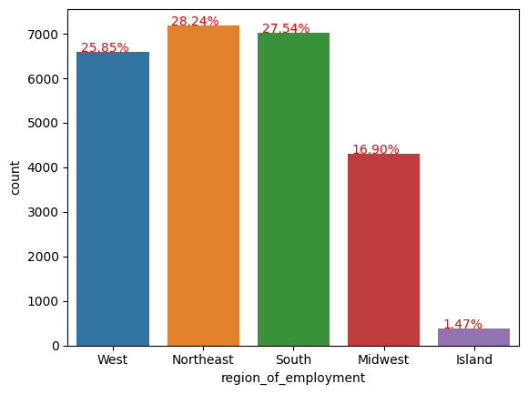

```python
# Univariate analysis for region_of_employment
count('region_of_employment',evisa_df)
```

As you can see 28.24% application is for Northeast region followed by 27.54% for South region. Only 1.47% application is for Island region.

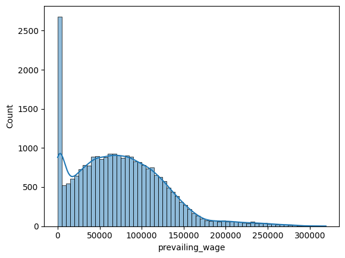

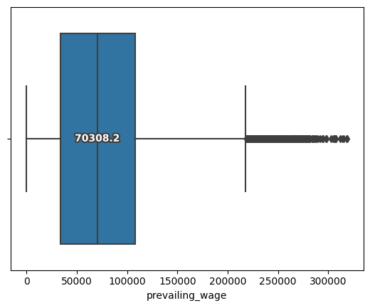

```python
# Univariate analysis for yrs_since_estab
hist('prevailing_wage',evisa_df,True)
box('prevailing_wage',evisa_df)
```

As you can see Prevailing wage has mean of 74455.8 and median value is 70308. Minimum value is 2.1367 and maximum value is 319210.27. There are almost 2600 data points with Prevailing wages less then 5000 dollar so we might want to check the unit_of_wage for those data points.

```python
# Checking to see what is unit_of_wage for datapoint with prevailing wage less then 5000 dollar
evisa_df[evisa_df['prevailing_wage'] <= 5000]['unit_of_wage'].value_counts()
```

```
Hour     2157
Year      518
Week        4
Month       3
Name: unit_of_wage, dtype: int64
```

Most of the data points is from Hour unit of wage so we do not have to treat those points.

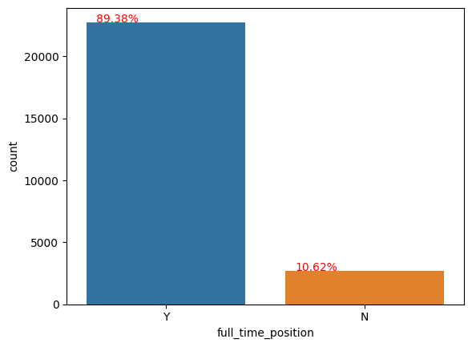

```python
# Univariate analysis for full_time_position
count('full_time_position',evisa_df)
```

Almost 89.38% application is for Full time position and only 10.62% application is not for full time position.

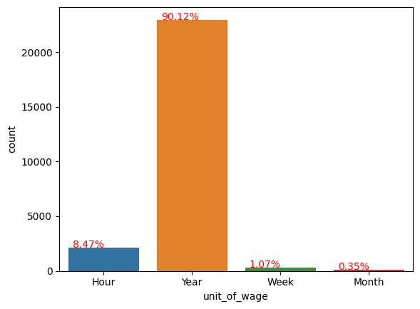

```python
# Univariate analysis for unit_of_wage
count('unit_of_wage',evisa_df)
```

Almost 90.12% application has prevailing wage in Year followed by only 8.47% application has prevailing wage in Hour.

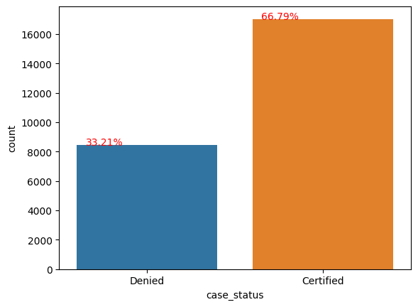

```python
# Univariate analysis for case_status
count('case_status',evisa_df)
```

Almost 66.79% application has been certified and remaining 33.21% application has been denied.

```python
# Treatment for education_of_employee and case_status
replaceStruct = {
                "education_of_employee":     {"High School": 1, "Bachelor's": 2 ,"Master's": 3 ,"Doctorate":4},
                "case_status":     {"Denied": 0, "Certified": 1 }
                    }
```

```python
evisa_df = evisa_df.replace(replaceStruct)
```

```python
evisa_df.head()
```

|  | continent | education_of_employee | has_job_experience | requires_job_training | no_of_employees | yr_of_estab | region_of_employment | prevailing_wage | unit_of_wage | full_time_position | case_status | yrs_since_estab | Yearly_wage |
| --- | --- | --- | --- | --- | --- | --- | --- | --- | --- | --- | --- | --- | --- |
| 0 | Asia | 1 | N | N | 14513 | 2007 | West | 592.2029 | Hour | Y | 0 | 9 | 1231782.032 |
| 1 | Asia | 3 | Y | N | 2412 | 2002 | Northeast | 83425.6500 | Year | Y | 1 | 14 | 83425.650 |
| 2 | Asia | 2 | N | Y | 44444 | 2008 | West | 122996.8600 | Year | Y | 0 | 8 | 122996.860 |
| 3 | Asia | 2 | N | N | 98 | 1897 | West | 83434.0300 | Year | Y | 0 | 119 | 83434.030 |
| 4 | Africa | 3 | Y | N | 1082 | 2005 | South | 149907.3900 | Year | Y | 1 | 11 | 149907.390 |

```python
# Dropping year_of_estab and using yrs_since_estab
evisa_df.drop(['yr_of_estab'],axis=1,inplace=True)
```

# **Bi Variate Analysis**

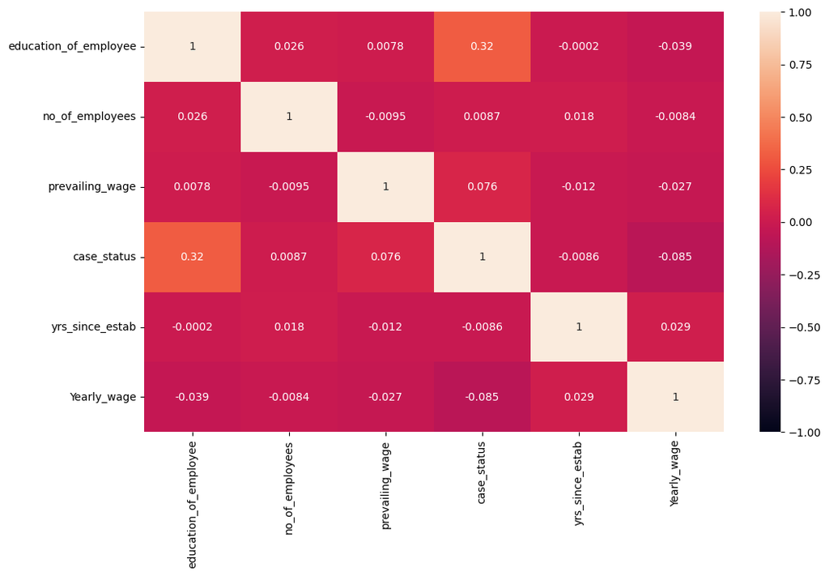

```python
# Heat plot for all numeric variable
plt.figure(figsize=(12, 7))
sns.heatmap(evisa_df.corr(), annot=True, vmin=-1, vmax=1)
plt.show()
```

As you can see case_status is in positive correlation with education_of_employee with factor of 0.32.

**Experienced professionals might look abroad for opportunities to improve their lifestyles and career development. Does work experience influence visa status?**

```
has_job_experience  case_status
N                   1              0.561341
                    0              0.438659
Y                   1              0.744764
                    0              0.255236
Name: case_status, dtype: float64
```

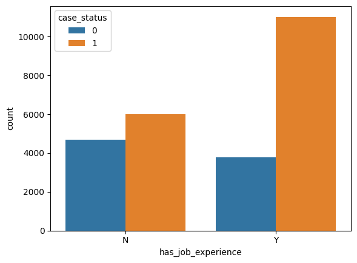

```python
# Bivariate analysis for has_job_experience vs case_status
sns.countplot(x='has_job_experience',data=evisa_df,hue='case_status')
evisa_df.groupby('has_job_experience')['case_status'].value_counts(normalize=True)
```

As you can see applicant with job experience has 74.47% chances of certifying for the visa application while without job experience has only 56.13% chances of certifying. With work experience your chances of getting visa approval is high.

```
requires_job_training  case_status
N                      1              0.666459
                       0              0.333541
Y                      1              0.678849
                       0              0.321151
Name: case_status, dtype: float64
```

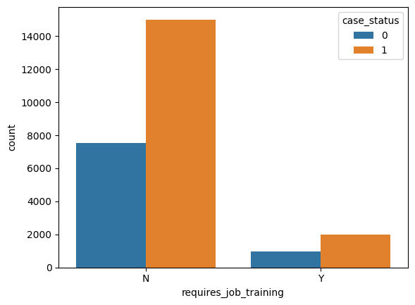

```python
# Bivariate analysis for requires_job_training vs case_status
sns.countplot(x='requires_job_training',data=evisa_df,hue='case_status')
evisa_df.groupby('requires_job_training')['case_status'].value_counts(normalize=True)
```

As you can require_job_training has not much impact on case status but most of the applicant does not need training.

**Those with higher education may want to travel abroad for a well-paid job. Does education play a role in Visa certification?**

```
education_of_employee  case_status
1                      0              0.659649
                       1              0.340351
2                      1              0.622142
                       0              0.377858
3                      1              0.786278
                       0              0.213722
4                      1              0.872263
                       0              0.127737
Name: case_status, dtype: float64
```

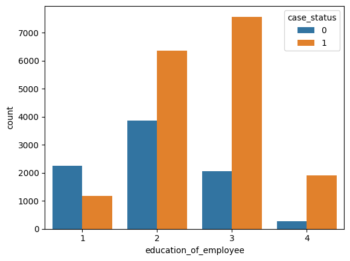

```python
# Bivariate analysis for education_of_employee vs case_status
sns.countplot(x='education_of_employee',data=evisa_df,hue='case_status')
evisa_df.groupby('education_of_employee')['case_status'].value_counts(normalize=True)
```

As you can see applicant with higher education degree has more chances of getting approval. Applicant with High school degree has only 34% chances of visa approval. Applicant with Bacheloers and Masters degree has 62.2% and 78.67% chances of getting approval respectively. Applicant with Phd has almost 87.22% of getting approval.

**How does the visa status vary across different continents?**

```
continent      case_status
Africa         1              0.720508
               0              0.279492
Asia           1              0.653105
               0              0.346895
Europe         1              0.792337
               0              0.207663
North America  1              0.618773
               0              0.381227
Oceania        1              0.635417
               0              0.364583
South America  1              0.578638
               0              0.421362
Name: case_status, dtype: float64
```

```
continent      case_status
Africa         1                397
               0                154
Asia           1              11012
               0               5849
Europe         1               2957
               0                775
North America  1               2037
               0               1255
Oceania        1                122
               0                 70
South America  1                493
               0                359
Name: case_status, dtype: int64
```

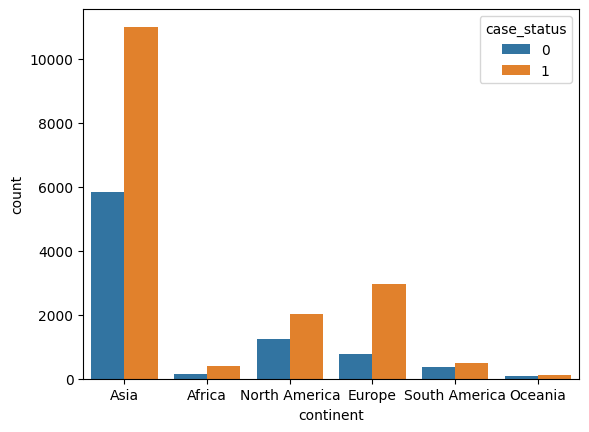

```python
# Bivariate analysis for continent vs case_status
sns.countplot(x='continent',data=evisa_df,hue='case_status')
display(evisa_df.groupby('continent')['case_status'].value_counts(normalize=True))
display(evisa_df.groupby('continent')['case_status'].value_counts())
```

Applicant from Europe has almost 79.23% chances of getting approval followed by Africa with 72.05%. Almost 66% applicants are from Asia and they have 65.31% chances of approval.

```
full_time_position  case_status
N                   1              0.685260
                    0              0.314740
Y                   1              0.665832
                    0              0.334168
Name: case_status, dtype: float64
```

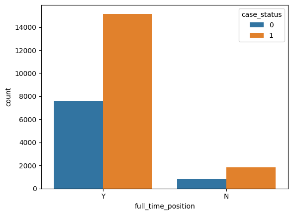

```python
# Bivariate analysis for full_time_position vs case_status
sns.countplot(x='full_time_position',data=evisa_df,hue='case_status')
evisa_df.groupby('full_time_position')['case_status'].value_counts(normalize=True)
```

**In the United States, employees are paid at different intervals. Which pay unit is most likely to be certified for a visa?**

```
unit_of_wage  case_status
Hour          0              0.653686
              1              0.346314
Month         1              0.617978
              0              0.382022
Week          1              0.621324
              0              0.378676
Year          1              0.698850
              0              0.301150
Name: case_status, dtype: float64
```

```
unit_of_wage  case_status
Hour          0               1410
              1                747
Month         1                 55
              0                 34
Week          1                169
              0                103
Year          1              16047
              0               6915
Name: case_status, dtype: int64
```

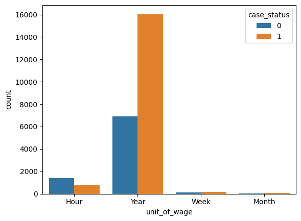

```python
# Bivariate analysis for unit_of_wage vs case_status
sns.countplot(x='unit_of_wage',data=evisa_df,hue='case_status')
display(evisa_df.groupby('unit_of_wage')['case_status'].value_counts(normalize=True))
display(evisa_df.groupby('unit_of_wage')['case_status'].value_counts())
```

As you did see earlier almost 90% application has prevailing wage in Year followed by only 8.47% application has prevailing wage in Hour. As you can see applicant with prevailing wage unit Year has almost 70% chances of approval compared with Hour which has only 34.63% chances of approval.Applcation with prevailing wage in Months and Week has 61.79% and 62.13% chances of appproval.

```
case_status
0    267128.094611
1    162715.283782
Name: Yearly_wage, dtype: float64
```

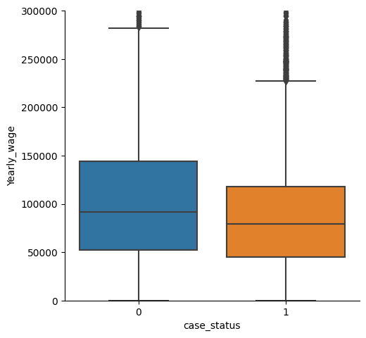

```python
# Yearly_wage vs case_status
plt.figure(figsize=(20, 7))
ax = sns.catplot(x='case_status',y='Yearly_wage',data=evisa_df,kind='box')
ax.set(ylim=(0,300000))
evisa_df.groupby('case_status')['Yearly_wage'].mean()
```

```
region_of_employment  case_status
Island                1              0.602667
                      0              0.397333
Midwest               1              0.755282
                      0              0.244718
Northeast             1              0.629048
                      0              0.370952
South                 1              0.700157
                      0              0.299843
West                  1              0.622533
                      0              0.377467
Name: case_status, dtype: float64
```

```
region_of_employment  case_status
Island                1               226
                      0               149
Midwest               1              3253
                      0              1054
Northeast             1              4526
                      0              2669
South                 1              4913
                      0              2104
West                  1              4100
                      0              2486
Name: case_status, dtype: int64
```

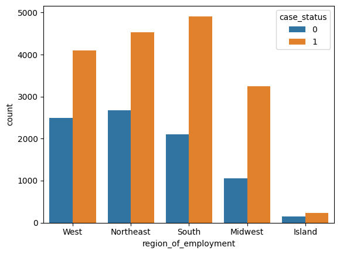

```python
# Bivariate analysis for region_of_employment vs case_status
sns.countplot(x='region_of_employment',data=evisa_df,hue='case_status')
display(evisa_df.groupby('region_of_employment')['case_status'].value_counts(normalize=True))
display(evisa_df.groupby('region_of_employment')['case_status'].value_counts())
```

As you can see appplicant with region of employment Midwest has 75.52% chance of approval followed by applicant with South with 70%.Applicant with Northeast,West and Island region of employment has 62.9%,62.3% and 60.26% chances of approval.

```
has_job_experience  requires_job_training
N                   N                        0.841731
                    Y                        0.158269
Y                   N                        0.914539
                    Y                        0.085461
Name: requires_job_training, dtype: float64
```

```
has_job_experience  requires_job_training
N                   N                         8988
                    Y                         1690
Y                   N                        13537
                    Y                         1265
Name: requires_job_training, dtype: int64
```

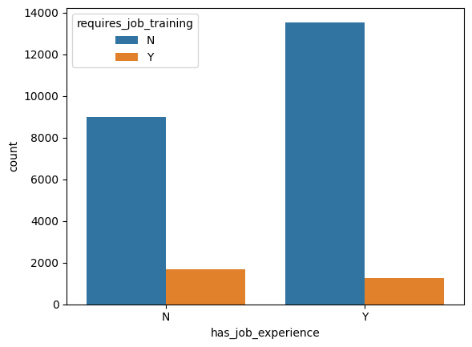

```python
# Bivariate analysis for has_job_experience with requires_job_training
sns.countplot(x='has_job_experience',data=evisa_df,hue='requires_job_training')
display(evisa_df.groupby('has_job_experience')['requires_job_training'].value_counts(normalize=True))
display(evisa_df.groupby('has_job_experience')['requires_job_training'].value_counts())
```

As you can see 91.45% of applicant with job experience does not need training compared with 84.17% applicant without job experience does not need training.

```
case_status
0    5385.601040
1    5807.055882
Name: no_of_employees, dtype: float64
```

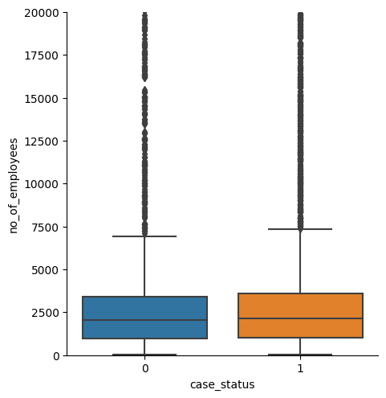

```python
# no_of_employees vs case_status
plt.figure(figsize=(20, 7))
ax = sns.catplot(x='case_status',y='no_of_employees',data=evisa_df,kind='box')
ax.set(ylim=(0,20000))
evisa_df.groupby('case_status')['no_of_employees'].mean()
```

**The US government has established a prevailing wage to protect local talent and foreign workers. How does the visa status change with the prevailing wage?**

```
case_status  unit_of_wage
0            Hour              409.085998
             Month           88167.630882
             Week            85003.102233
             Year            82345.844294
1            Hour              424.922811
             Month           87237.553636
             Week            85974.767160
             Year            80746.407044
Name: prevailing_wage, dtype: float64
```

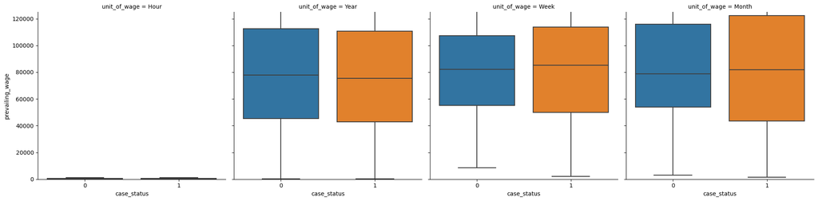

```python
# prevailing_wage vs case_status with unit_of_wage
plt.figure(figsize=(20, 7))
ax = sns.catplot(x='case_status',y='prevailing_wage',data=evisa_df,kind='box',col='unit_of_wage')
ax.set(ylim=(0,125000))
evisa_df.groupby(['case_status','unit_of_wage'])['prevailing_wage'].mean()
```

As you can see Prevailing wage for applicant whose case is approved or denied are almost similar for there unit of wage. So prevailing wage for applicant with Year as unit of wage is dollar 80746 for certified case status and dollar 82345 for denied case status.

```
region_of_employment  unit_of_wage
Island                Hour               275.653606
                      Week            126253.246667
                      Year             96069.378616
Midwest               Hour               427.295586
                      Month           103304.350769
                      Week             90037.835938
                      Year             94910.426249
Northeast             Hour               406.198381
                      Month            79865.462069
                      Week             79328.718152
                      Year             77045.918330
South                 Hour               425.968982
                      Month            86509.104643
                      Week             87433.838971
                      Year             82068.799259
West                  Hour               414.457558
                      Month            90234.474211
                      Week             88069.371039
                      Year             74487.099762
Name: prevailing_wage, dtype: float64
```

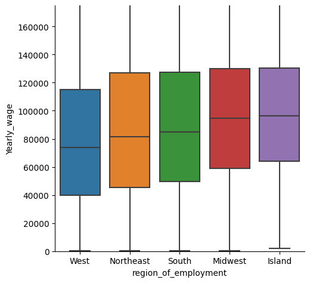

```python
# prevailing_wage vs region_of_employment
plt.figure(figsize=(20, 7))
ax = sns.catplot(x='region_of_employment',y='Yearly_wage',data=evisa_df,kind='box')
ax.set(ylim=(0,175000))
evisa_df.groupby(['region_of_employment','unit_of_wage'])['prevailing_wage'].mean()
```

As you can see that yearly prevailing wages are higher in Island region followed by Midwest,South,Northeast and West region

## **Data Preprocessing**

- Missing value treatment (if needed)
- Feature engineering
- Outlier detection and treatment (if needed)
- Preparing data for modeling
- Any other preprocessing steps (if needed)

### **Missing value treatment**

```python
evisa_df.isna().sum()
```

```
continent                0
education_of_employee    0
has_job_experience       0
requires_job_training    0
no_of_employees          0
region_of_employment     0
prevailing_wage          0
unit_of_wage             0
full_time_position       0
case_status              0
yrs_since_estab          0
Yearly_wage              0
dtype: int64
```

**There are no missing values**

```python
evisa_df.describe().T
```

|  | count | mean | std | min | 25% | 50% | 75% | max |
| --- | --- | --- | --- | --- | --- | --- | --- | --- |
| education_of_employee | 25480.0 | 2.415934 | 0.826718 | 1.0000 | 2.000 | 2.00 | 3.0000 | 4.00 |
| no_of_employees | 25480.0 | 5667.089207 | 22877.917453 | 11.0000 | 1022.000 | 2109.00 | 3504.0000 | 602069.00 |
| prevailing_wage | 25480.0 | 74455.814592 | 52815.942327 | 2.1367 | 34015.480 | 70308.21 | 107735.5125 | 319210.27 |
| case_status | 25480.0 | 0.667896 | 0.470977 | 0.0000 | 0.000 | 1.00 | 1.0000 | 1.00 |
| yrs_since_estab | 25480.0 | 36.590071 | 42.366929 | 0.0000 | 11.000 | 19.00 | 40.0000 | 216.00 |
| Yearly_wage | 25480.0 | 197391.155259 | 578591.666314 | 100.0000 | 47107.965 | 82839.46 | 124825.0350 | 14569149.40 |

### **Checking for Outliers**

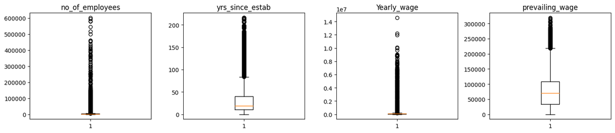

```python
# outlier detection using boxplot
# selecting the numerical columns of data and adding their names in a list
numeric_columns = ['no_of_employees', 'yrs_since_estab','Yearly_wage','prevailing_wage']
plt.figure(figsize=(15, 12))

for i, variable in enumerate(numeric_columns):
    plt.subplot(4, 4, i + 1)
    plt.boxplot(evisa_df[variable], whis=1.5)
    plt.tight_layout()
    plt.title(variable)

plt.show()
```

```python
# to find the 25th percentile and 75th percentile for the numerical columns.
Q1 = evisa_df[numeric_columns].quantile(0.25)
Q3 = evisa_df[numeric_columns].quantile(0.75)

IQR = Q3 - Q1                   #Inter Quantile Range (75th percentile - 25th percentile)

lower_whisker = Q1 - 1.5*IQR    #Finding lower and upper bounds for all values. All values outside these bounds are outliers
upper_whisker = Q3 + 1.5*IQR
```

```python
# Percentage of outliers in each column
((evisa_df[numeric_columns] < lower_whisker) | (evisa_df[numeric_columns] > upper_whisker)).sum()/evisa_df.shape[0]*100
```

```
no_of_employees     6.106750
yrs_since_estab    12.794349
Yearly_wage         9.368132
prevailing_wage     1.675824
dtype: float64
```

Most of the outlier present in the data are seems to be normal.

```python
# Making copy of data
evisa_df3 = evisa_df.copy()
```

```python
# Dropping Yearly wage column as applicant might not be working throught the year for wage based on Hour or Month or Weekly basis
evisa_df.drop(['Yearly_wage'],axis=1,inplace=True)
```

```python
# Creating dummy variables
evisa_df = pd.get_dummies(evisa_df, columns=['continent','has_job_experience','requires_job_training', 'region_of_employment','full_time_position','unit_of_wage'],drop_first=True)
```

```python
# Checking all the columns
evisa_df.info()
```

```
<class 'pandas.core.frame.DataFrame'>
RangeIndex: 25480 entries, 0 to 25479
Data columns (total 20 columns):
 #   Column                          Non-Null Count  Dtype
---  ------                          --------------  -----
 0   education_of_employee           25480 non-null  int64
 1   no_of_employees                 25480 non-null  int64
 2   prevailing_wage                 25480 non-null  float64
 3   case_status                     25480 non-null  int64
 4   yrs_since_estab                 25480 non-null  int64
 5   continent_Asia                  25480 non-null  uint8
 6   continent_Europe                25480 non-null  uint8
 7   continent_North America         25480 non-null  uint8
 8   continent_Oceania               25480 non-null  uint8
 9   continent_South America         25480 non-null  uint8
 10  has_job_experience_Y            25480 non-null  uint8
 11  requires_job_training_Y         25480 non-null  uint8
 12  region_of_employment_Midwest    25480 non-null  uint8
 13  region_of_employment_Northeast  25480 non-null  uint8
 14  region_of_employment_South      25480 non-null  uint8
 15  region_of_employment_West       25480 non-null  uint8
 16  full_time_position_Y            25480 non-null  uint8
 17  unit_of_wage_Month              25480 non-null  uint8
 18  unit_of_wage_Week               25480 non-null  uint8
 19  unit_of_wage_Year               25480 non-null  uint8
dtypes: float64(1), int64(4), uint8(15)
memory usage: 1.3 MB
```

### **Preparing data for modelling**

```python
# Assigning X and y
X = evisa_df.drop("case_status" , axis=1)
y = evisa_df.pop("case_status")
```

```python
# Using train test split method
X_train, X_test, y_train, y_test = train_test_split(X, y, test_size=.30, random_state=1,stratify=y)
```

```python
# Function to evaluate model performance
def score(model,train,act,desc):
    """
      Inputs:
      Used to evaluate and check model performance
      model: model used to fit the data
      train : training set or testing set or X
      pred: predicted y using model
      act: actual data from dataset or y
      desc: just for printing to make sure test or train

      Outputs:
      Recall,Precesion,Accuracy,F1 score

    """
    pred = model.predict(train)
    pc_test = precision_score(act, pred)
    print("The precision score is {pc:.3f}".format(pc = pc_test))
    rc_test = recall_score(act, pred)
    print("The recall score is {rc:.3f}".format(rc = rc_test))
    ac_test = accuracy_score(act, pred)
    print("The accuracy score is {ac:.3f}".format(ac = ac_test))
    f1_test = f1_score(act, pred)
    print("The F1 score is {f1:.3f}".format(f1 = f1_test))
# defining a function to plot the confusion_matrix of a classification model
    cm = confusion_matrix(act, pred)
    plt.figure(figsize=(7, 5))
    sns.heatmap(cm, annot=True, fmt="g")
    plt.xlabel("Predicted Values")
    plt.ylabel("Actual Values")
    plt.show()
# Printing result
    df_pred = pd.DataFrame()
    df_pred["Recall"] = [rc_test]
    df_pred["Precesion"] = [pc_test]
    df_pred["Accuracy"] = [ac_test]
    df_pred["F1_score"] = [f1_test]
    print( "Result for the",desc,"model are:",'\n')
    return df_pred
```